# Fragrance Market Exploration

[figure not shown]

## I. Introduction

As the gloom of the pandemic lingers and the global economy faces a downturn, the once-reliable **“lipstick effect”** appears to be losing its validity. The term “lipstick effect” originated during the Great Depression in the 1930s in the United States, referring to the economic phenomenon where although overall consumption declines during a recession, sales of inexpensive discretionary goods like lipstick increase. **Fast forward to 2024, while the overall beauty market is experiencing slowed growth or even a slight decline, the fragrance category has emerged as a standout category.**

**Firstly, the fragrance market has somewhat bolstered the performance of the international beauty industry.** According to Euromonitor data, the global fragrance and perfume market is estimated to reach approximately $60 billion in 2024. Half-year reports for 2024 reveal that the fragrance business of Estée Lauder Group became the only growing segment among its four product lines this fiscal year, with its representative fragrance brand Le Labo achieving double-digit growth in net sales. Similarly, financial reports from L’Oréal Group and LVMH Group indicate that fragrances have leapfrogged to become the most dynamic and growth-potential segment in the premium cosmetics division. Clearly, fragrances have become a new growth engine for international groups amid the beauty industry’s winter. Even against the backdrop of significantly slowed commercial growth this year, the fragrance category’s market performance remains robust compared to other cosmetic categories.

**Moreover, under the wave of digitalization, traditional fragrance brands urgently need to prioritize their e-commerce strategy.** The rapid development of the internet and e-commerce has reshaped the sales landscape of fragrances. Online shopping platforms, with their convenience, information richness, and 24/7 operation, have broken the spatiotemporal constraints of traditional offline retail, attracting a massive influx of consumers to the online fragrance market. On one hand, this provides brands with low-cost, high-exposure entry opportunities; on the other hand, it forces brands to quickly adapt to dynamic market changes.

**Finally, the accords of fragrance products and the current “self-pleasure” consumption concept have become critical factors determining product success.** According to iiMedia Research data, 64.2% of consumers stated that daily fragrance use is more focused on pleasing themselves and obtaining diverse emotional value. The consumption scenarios for fragrances are broadening, and the uniqueness of scents has become a new trend in fragrance selection. Consumers are increasingly inclined to interpret their individuality and taste through unique aromas and pursue distinctive aesthetic experiences to achieve the ultimate consumption goal of “self-pleasure”.

Based on apparent popularity and future market potential, this report aims to discuss the future direction of the fragrance market, or “olfactory economy”, in 2024 from the three aforementioned perspectives: market, brand e-commerce, and product scents:

**1. Market Trend Analysis:** How is the fragrance market developing?

**2. Brand Strategy Analysis:** What are the differences in strategic choices among brands in the e-commerce battlefield?

**3. Product Scent Analysis:** On demand side, how do consumer accept different accords (i.e., accords)? On supply side, which accord combinations do brands frequently use?

## II. Data Source

This report utilizes two datasets, both sourced from Kaggle, described as follows:

### 1. Parfumo Data

Parfumo(https://www.parfumo.com/) is a tight-knit community of fragrance connoisseurs and enthusiasts where users can discover new fragrances, rate, and review them. The dataset was authored by OLGA G (MIUFANA1), who scraped detailed fragrance information from the Parfumo website. After cleaning, it includes 59,315 entries featuring attributes such as fragrance product name, brand, release year, concentration, scent notes, ratings, price, etc. The data was updated in September 2024.

### 2. eBay Data

eBay(https://www.ebay.com/) is a well-known e-commerce platform where global consumers can purchase or view goods through retail sales. The dataset was authored by KANCHANA1990, who scraped detailed information from 2,000 fragrance listings on eBay, split equally into 1,000 entries each for men’s and women’s fragrances. It showcases current market pricing, supply conditions, sales status, and other information in the e-commerce landscape for fragrances. The data was updated in June 2024.

```r
# Data Preparation
library(tidyverse)
library(ggrepel)
library(moments)
library(stringr)
library(igraph)
library(networkD3)
library(htmlwidgets)

perfumes <- as_tibble(read.csv("parfumo.csv",header = T,stringsAsFactors = F)) %>%
    filter(Name != "Name")    # Remove dirty data
sales_w <- as_tibble(read.csv("ebay_women.csv",header = T,stringsAsFactors = F))
sales_m <- as_tibble(read.csv("ebay_men.csv",header = T,stringsAsFactors = F))
```

## III. Analysis

### 1. Market Trend Analysis

First, by selecting perfumes launched from 1910 to the present, it is evident that **in the first half of the 20th century, the number of perfume releases was relatively low and stable, with slow growth. Starting from the 1980s, the number of perfume releases showed a rapid growth trend, especially after 2010, with a significant increase, reaching a high level between 2015 and 2019, though it has declined somewhat in recent years.** The color depth represents the number of ratings collected by Parfumo. It can be observed that newly launched perfumes receive more ratings, which is closely related to the development of the internet in recent years.

**This aligns with our understanding of the development trajectory of the perfume market**: In the early days, the complex production process of perfumes led to low efficiency, limiting both output and the number of new product launches. Additionally, the consumer market was primarily concentrated among a small affluent class, resulting in relatively low market demand, which gave perfume brands little incentive to launch a large number of new products. After the 1980s, with the development of the global economy and improvements in living standards, consumer demand for perfumes gradually expanded, and market potential was continuously tapped. To meet the needs and preferences of diverse consumers, perfume brands began to increase efforts in R&D and new product launches. The recent decline in the number of new releases is due to market saturation and factors such as the pandemic, which caused fluctuations in the global economic landscape, leading brands to be more cautious in new product development and launch.

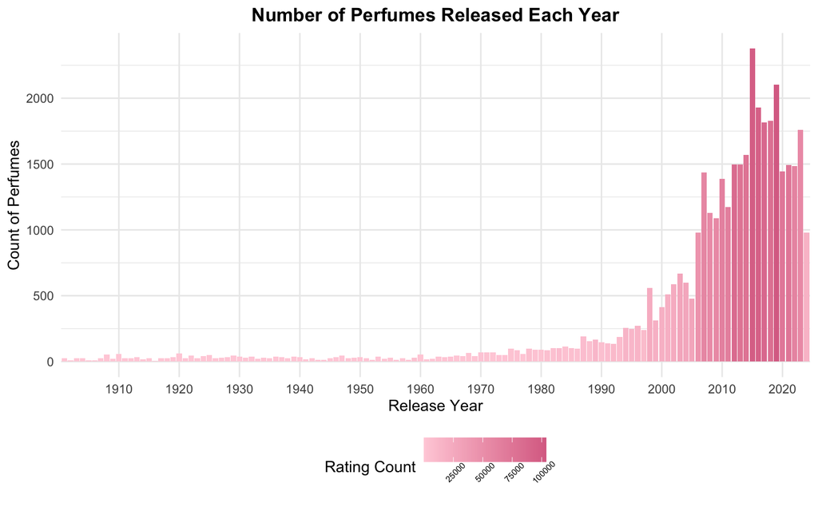

```r
# Process the rating count field
perfumes$Rating.Count <- as.numeric(
  gsub("\\D", "",
       ifelse(perfumes$Rating.Count == "N/A", 0, perfumes$Rating.Count)
       ))

# Count the number of perfumes and ratings per year
year_summary <- perfumes %>%
  group_by(Release.Year) %>%
  summarize(
    Perfume.Count = n(),   # Number of perfumes released each year
    Rating.Count = sum(Rating.Count)  # number of rating times each year
  ) %>%
  filter(Release.Year!= "N/A" & Release.Year!= "Release Year" & Release.Year > 1900) %>%
  arrange(Release.Year)

# Plot
ggplot(year_summary, aes(x = Release.Year, y = Perfume.Count, fill = Rating.Count)) +
  geom_bar(stat = "identity", position = "dodge") +
  labs(title = "Number of Perfumes Released Each Year",
       x = "Release Year",
       y = "Count of Perfumes",
       fill = "Rating Count") +
  scale_fill_gradient(low = "#FFD1DC", high ="#DB7093")+
  theme_minimal() +
  theme(plot.title = element_text(hjust = 0.5, face = "bold"),
        legend.text = element_text(angle = 45,size = 6),
        legend.position = "bottom") +
  scale_x_discrete(breaks = seq(1900, 2020, by = 10),
                   labels = c("1900", "1910", "1920", "1930", "1940", "1950", "1960", "1970", "1980", "1990", "2000", "2010", "2020"))
```

A possible factor I speculate is that modern consumers increasingly seek uniqueness and personalization in perfumes. Eau de Parfum typically offers a more intense and long-lasting fragrance, better showcasing personal charm and style, and meeting consumers’ desires to express themselves on special occasions or in daily use. As a result, Eau de Parfum has gradually dominated the market.

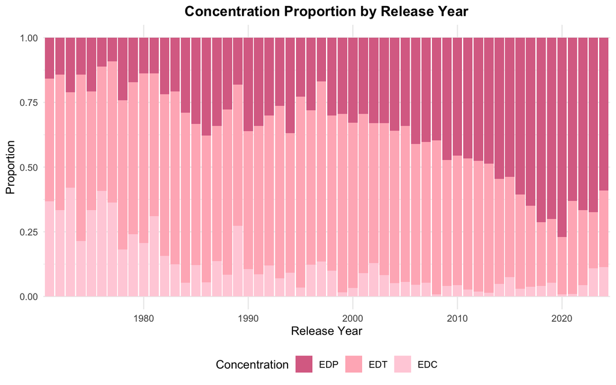

```r
# Classify perfumes by year and concentration
# The concentration classification in the data source is too detailed; I reclassify into EDC/EDT/EDP based on market consensus using text recognition
step1 <- perfumes %>%
  filter(Release.Year!= "N/A" & Release.Year!= "Release Year" & Release.Year > 1970) %>%
  filter(Concentration!= "N/A") %>%
  mutate(Concentration_New = case_when(
    str_detect(Concentration, regex("Eau de Toilette", ignore_case = TRUE)) ~ "EDT",
    str_detect(Concentration, regex("Eau de Parfum", ignore_case = TRUE)) ~ "EDP",
    str_detect(Concentration, regex("Cologne", ignore_case = TRUE)) ~ "EDC",
    TRUE ~ "Other"
  )) %>%
  group_by(Release.Year, Concentration_New) %>%
  summarise(cnt = n())

# Calculate total perfumes per year
step2 <- step1 %>%
  group_by(Release.Year) %>%
  mutate(total_cnt = sum(cnt)) %>%
  ungroup()

# Calculate proportion of each concentration per year
final_result <- step2 %>%
  filter(Concentration_New!= "Other") %>%
  mutate(proportion = cnt / total_cnt)

# Plot
final_result$Concentration_New <- factor(final_result$Concentration_New, levels = c("EDP", "EDT", "EDC"))
ggplot(final_result, aes(x = Release.Year, fill = Concentration_New)) +
  geom_bar(aes(weight = proportion), position = "fill") +
  labs(x = "Release Year",
       y = "Proportion",
       title = "Concentration Proportion by Release Year",
       fill = "Concentration")+
  scale_fill_manual(values = c("EDC" = "#FFD1DC", "EDT" = "#FFB6C1", "EDP" = "#DB7093")) +
  theme_minimal()+
  theme(plot.title = element_text(hjust = 0.5, face = "bold"),
        legend.position = "bottom")+
  scale_x_discrete(breaks = seq(1970, 2020, by = 10),
                   labels = c("1970", "1980", "1990", "2000", "2010", "2020"))
```

### 2. Brand Strategy Analysis

The chart below shows the differences in e-commerce strategies among the top 10 perfume brands on eBay in 2024: The horizontal axis represents the number of perfume products per brand, the vertical axis represents the average price of products (USD), bubble color indicates the female dominance index (proportion of women’s perfumes in the product matrix), and bubble size represents e-commerce sales.

It can be observed that brands adopt **diverse strategic choices** in the e-commerce battlefield based on their brand positioning, target consumer groups, and market competition: some focus on product variety, others emphasize premium pricing and brand image, while some have different gender market positioning. These strategies collectively form a diversified competitive landscape in the perfume market’s e-commerce channel. **The chart is divided into four quadrants for discussion:**

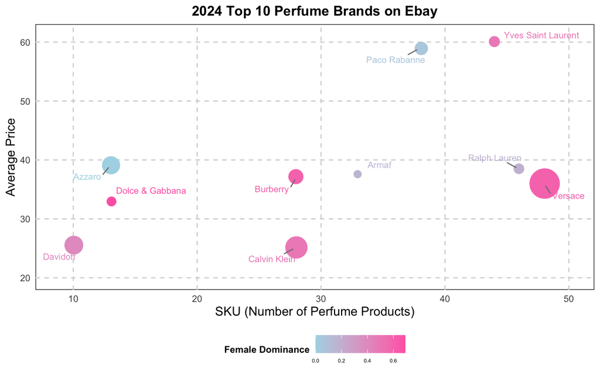

```r
# Add women's/men's perfume flags to sales_w and sales_m
sales_w <- sales_w %>%
  mutate(female_flag = 1, male_flag = 0)
sales_m <- sales_m %>%
  mutate(female_flag = 0, male_flag = 1)

# Merge data and calculate group statistics
combined_data <- bind_rows(sales_w, sales_m) %>%
  filter(price != 0 & sold != 0 & type %in% c('Eau de Toilette', 'Eau de Parfum')) %>%
  group_by(brand) %>%
  summarize(
    num_perfumes = n(),
    total_sales = sum(price * sold),
    avg_price = mean(price),
    female_perfume_count = sum(female_flag),
    male_perfume_count = sum(male_flag)
  ) %>%
  mutate(
    female_percentage = ifelse((female_perfume_count + male_perfume_count) == 0, 0, female_perfume_count / (female_perfume_count + male_perfume_count))
    # Self-defined variable: Female Dominance Index
  ) %>%
  top_n(10, total_sales)

# Plot
ggplot(combined_data, aes(x = num_perfumes, y = avg_price, size = total_sales , color = female_percentage)) +
  geom_point(position = position_jitter(width = 0.1, height = 0.1)) +
  geom_text_repel(aes(label = brand),
                  size = 3,
                  box.padding = 0.5,
                  point.padding = 0.5,
                  segment.color = "gray50",
                  segment.size = 0.5) +
  labs(title = "2024 Top 10 Perfume Brands on Ebay",
       x = "SKU (Number of Perfume Products)",
       y = "Average Price",
       color = "Female Dominance") +
  scale_color_gradient(low = "lightblue", high = "hotpink") +
  theme_minimal() +
  theme(axis.title.x = element_text(size = 12),
        axis.title.y = element_text(size = 12),
        plot.title = element_text(hjust = 0.5, face = "bold"),
        legend.position = "bottom",
        legend.title = element_text(size = 9, face = "bold"),
        legend.text = element_text(size = 5),
        panel.background = element_rect(fill = "white"),
        panel.grid.major = element_line(color = "lightgray", linetype = "dashed", size = 0.5),
        panel.grid.minor = element_blank()) +
  guides(size = "none") +
  scale_size(range = c(3, 13)) +
  scale_x_continuous(limits = c(9, 50), breaks = seq(10, 50, by = 10)) +
  scale_y_continuous(limits = c(20, 61), breaks = seq(20, 60, by = 10))
```

#### 1) Bottom-left quadrant: Few products + Low prices

**Representative brands: Dolce & Gabbana, Davidoff**

These brands maintain a relatively streamlined product portfolio, focusing on a few iconic perfume products. By controlling product quantity, they reduce operational costs and management complexity. Their pricing strategy targets the affordable segment, aiming to attract a broad consumer base, especially price-sensitive consumers with perfume needs. This approach often targets the mass market and younger consumers, helping brands quickly expand market share and enhance brand awareness.

#### 2) Top-left quadrant: Few products + High prices

**Representative brand: Azzaro**

These brands follow a boutique strategy, focusing on creating a few high-quality perfumes with distinctive styles and brand identity. Through meticulous development of core products, they establish a premium brand image and reputation. Their high pricing aligns with this positioning, reflecting significant investment in R&D (e.g., rare ingredients, unique formulations, exquisite packaging) and brand storytelling. This attracts consumers willing to pay for quality and brand prestige, typically those seeking uniqueness and personalization.

#### 3) Top-right quadrant: Many products + High prices

**Representative brand：Paco Rabanne**

These brands offer a diverse product range, covering various consumer preferences through an extensive portfolio. Despite high product counts, they maintain premium pricing, indicating a focus on quality and brand image alongside variety. This dual strategy satisfies diverse consumer needs while attracting high-end customers seeking quality and brand prestige, particularly affluent consumer groups.

#### 4) Bottom-right quadrant: Many products + Low prices

**Representative brand: Calvin Klein**

These brands offer a moderate number of products with good variety, providing consumers with multiple choices. Their low-price strategy targets the mass market, emphasizing value for money. They likely achieve this through economies of scale, optimized supply chains, and efficient production. This approach appeals to price-sensitive consumers, especially younger demographics and the mass market, helping brands expand market coverage and increase sales volume.

Additionally, regarding **gender positioning**: Dolce & Gabbana and Yves Saint Laurent show high female dominance, focusing on the women’s market; Azzaro and Armaf show low female dominance, targeting more neutral or masculine positioning. Interestingly, top brands overall show balanced gender representation, challenging the perception of female dominance in perfumes. In reality, **gender fluidity is becoming the norm in the perfume market, with many fragrances evolving from traditional gender labels to universal appeal across all gender identities.**

*Note: This analysis uses eBay data sampling 2,000 perfume products, so these 10 brands may not represent eBay’s actual top sellers. Some well-known perfume brands are absent from the data. However, the discussion on brand strategy differentiation remains meaningful.*

### 3.Product Accord Analysis

#### 1) Demand Side: How Do Consumers Accept Different accords?

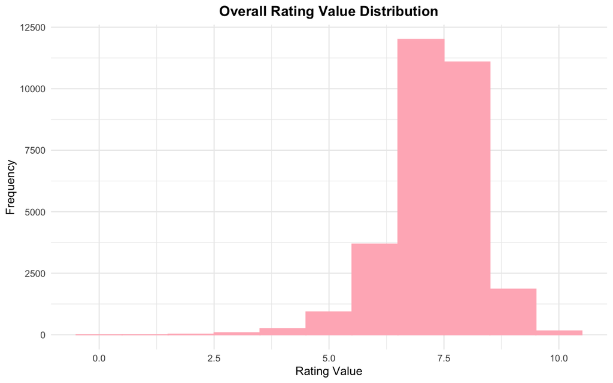

```r
perfumes$Rating.Value <- as.numeric(perfumes$Rating.Value)
ggplot(perfumes, aes(x = Rating.Value)) +
  geom_histogram(binwidth = 1,fill = "#FFB6C1", color = "#FFB6C1") +
  theme_minimal() +
  theme(plot.title = element_text(hjust = 0.5, face = "bold")) +
  labs(x = "Rating Value", y = "Frequency", title = "Overall Rating Value Distribution")
```

**However, the dispersion of ratings varies across accords.** For instance, ratings for floral scents are relatively concentrated, indicating consistent consumer evaluations. This is because the style of floral scents is clear and easily accepted by the public, making extreme rating differences less likely. In contrast, ratings for aquatic scents show greater variation. This is mainly because some Aquatic perfumes, when simulating aquatic notes, may suffer from overly chemical or unnatural smells due to issues with ingredient formulas or production techniques, leading to polarized ratings.

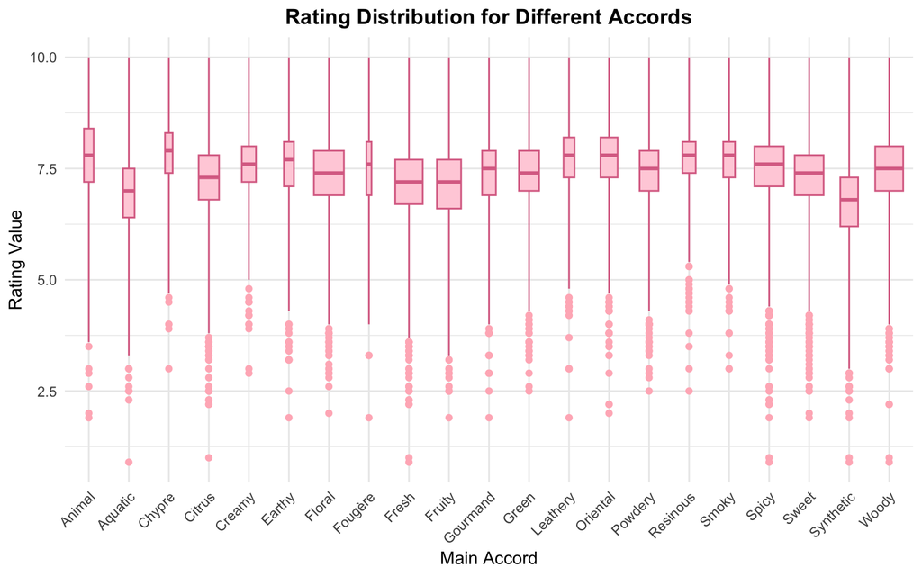

```r
# Text data processing
split_data <- lapply(perfumes$Main.Accords, strsplit, split = ",")
cleaned_data <- lapply(split_data, function(x) { lapply(x, trimws) })
split_vector <- unlist(cleaned_data)
accord <- data.frame(Main.Accords = split_vector, stringsAsFactors = F) %>%
  group_by(Main.Accords) %>%
  summarize(cnt = n())
merged_df <- accord %>%
  left_join(perfumes, by = character()) %>%
  mutate(match = str_detect(Main.Accords.y, Main.Accords.x)) %>%
  filter(match) %>%
  select(-match) %>%
  group_by(Main.Accords.x) %>%
  filter(Main.Accords.x!= "Main Accords" &!is.na(Rating.Value))

# Plot
unique_accords <- unique(merged_df$Main.Accords.x)
my_colors <- rep("#FFD1DC", length(unique_accords))
ggplot(merged_df,
       aes(x = Main.Accords.x, y = Rating.Value, fill = Main.Accords.x)) +
  geom_boxplot(varwidth = TRUE,
               coef = 3,
               outlier.colour = "#FFB6C1",
               color = "#DB7093") +
  theme_minimal() +
  theme(axis.text.x = element_text(angle = 45, hjust = 1),
        plot.title = element_text(hjust = 0.5,face = "bold")) +
  guides(size = "none") +
  labs(x = "Main Accord", y = "Rating Value",
       title = "Rating Distribution for Different Accords") +
  scale_fill_manual(values = my_colors) +
  guides(fill = "none")
```

#### 2）Supply Side: Which Accords Do Brands Tend to Combine?

**A single perfume often consists of multiple accords.** Next, using perfumes launched in 2024 as a sample, we transform the existing data into a network structure to explore how different accords are combined into a perfume.

**First, we identify 11 core accords from a total of 21.** In the graph, each node represents a accord, and the edge weights reflect the frequency with which two accords co-occur in the same perfume. The core subgraph includes accords that co-occur more frequently with others in perfumes, meaning these profiles are commonly used in perfume blending and their combinations are popular and widely accepted.

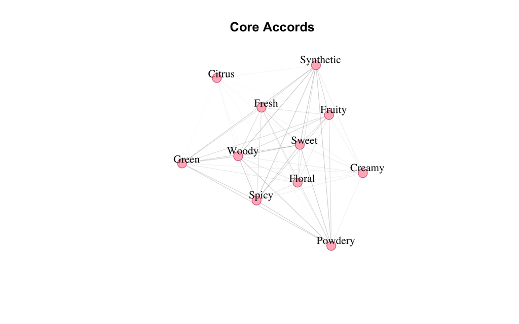

```r
# Data preprocessing
unique_accords <- unique(merged_df$Main.Accords.x)
new_perfumes <- perfumes[perfumes$Release.Year == 2024, ]

# Create the accord feature matrix
accord_feature_matrix <- matrix(0, nrow = nrow(new_perfumes), ncol = length(accord$Main.Accords))
colnames(accord_feature_matrix) <- accord$Main.Accords

for (i in 1:nrow(new_perfumes)) {
  current_perfume_accords <- strsplit(new_perfumes$Main.Accords[i], ",")[[1]]
  current_perfume_accords <- trimws(current_perfume_accords)

  for (j in 1:length(current_perfume_accords)) {
    accord_feature_matrix[i, which(unique_accords == current_perfume_accords[j])] <- 1
  }
}
col_vars <- apply(accord_feature_matrix, 2, var)
zero_var_cols <- which(col_vars == 0)
if (length(zero_var_cols) > 0) {
  accord_feature_matrix <- accord_feature_matrix[, -zero_var_cols]
}

# Create accords' co-occurrence matrix
valid_accords <- colnames(accord_feature_matrix)
co_occurrence_matrix <- matrix(0, nrow = length(valid_accords), ncol = length(valid_accords))
rownames(co_occurrence_matrix) <- valid_accords
colnames(co_occurrence_matrix) <- valid_accords


# Use loops to calculate and fill the co-occurrence matrix
for (i in 1:length(valid_accords)) {
  for (j in 1:length(valid_accords)) {
    # Skip diagonal elements (same accord) and keep as 0
    if (i == j) {
      next
    }
    # Initialize co-occurrence count for the current accord pair to 0
    co_count <- 0
    # Iterate through each perfume (each row of accord_feature_matrix)
    for (k in 1:nrow(accord_feature_matrix)) {
      # Check if the current accord pair co-occurs in the current perfume
      if (accord_feature_matrix[k, i] == 1 && accord_feature_matrix[k, j] == 1) {
        co_count <- co_count + 1
      }
    }
    # Assign the calculated co-occurrence count to the corresponding position in the co-occurrence matrix (symmetric assignment)
    co_occurrence_matrix[i, j] <- co_count
    co_occurrence_matrix[j, i] <- co_count
  }
}

# Identify core subgraph
W = co_occurrence_matrix
converg = FALSE
old.nrow = nrow(W)
while(!converg){
  in_degree = colSums(W)
  out_degree = rowSums(W)
  d = in_degree + out_degree
  to.keep = which(d >= 500)
  if(old.nrow == length(to.keep)){
    converg = TRUE
  }
  old.nrow = length(to.keep)
  W = W[to.keep,to.keep]
}
g_core = graph_from_adjacency_matrix(W, mode = "undirected", weighted = TRUE)

# Plot
set.seed(35)
plot(g_core,
     layout = layout.fruchterman.reingold,
     vertex.size = degree(g_core, mode = 'total'),
     vertex.shape = 'circle',
     vertex.color = '#FFB6C1',
     vertex.frame.color = '#DB7093',
     vertex.label = V(g_core)$Main.Accords,
     vertex.label.cex = 1,
     vertex.label.dist = 1,
     vertex.label.color = 'grey2',
     edge.width = E(g_core) * 0.008,
     main = "Core Accords")
```

**Second, we attempt to classify the 21 accords to identify which ones frequently co-occur—intuitively, accords that provide similar sensory experiences to consumers tend to appear together.** For example, Fruity and Floral scents both evoke a fresh feeling. Their co-occurrence not only maintains a consistent sensory experience but also offers consumers a unique experience through composite accords, making them an ideal choice for brands. Here, we use a community detection method to identify three major accord categories. accords within the same category tend to appear in the same perfume:

**i. Animal、Chypre、Earthy、Fougere、Leathery、Oriental、Woody、Spicy、Smoky、Resinous**

**Most of these accords evoke warm, rich, deep, or even mysterious feelings.** For example, Woody scents like sandalwood and cedar emit warm and steady aromas; Oriental scents often include spices and amber, offering exotic and warm characteristics; Spicy scents like cinnamon and clove provide a hot and warm olfactory experience; Smoky and Resinous scents evoke scenes of burning wood or resin, with heavy and unique smells.

**ii. Aquatic、Citrus、Fresh、Green**

**The common characteristic of this category is freshness, naturalness, and lightness.** For example, Aquatic scents evoke the ocean or rain; Citrus scents like lemon and orange emit bright, lively, and fresh aromas; Fresh scents may include green leaves, offering a clean olfactory experience; Green scents make one feel immersed in lush nature.

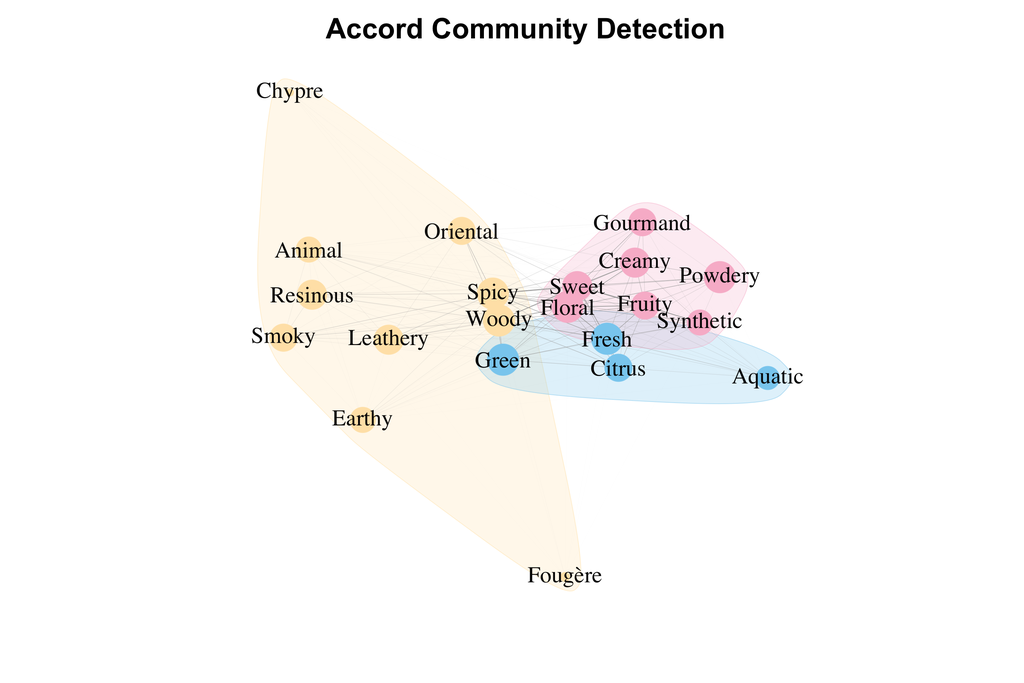

```r
# Generate color mapping function
assign_colors <- function(clusters) {
  num_clusters <- length(unique(membership(clusters)))
  if(num_clusters <= 8) {
    brewer.pal(num_clusters, "Set2")
  } else {
    hcl.colors(num_clusters, "Viridis")
  }
}
g <-  graph_from_adjacency_matrix(co_occurrence_matrix, mode = "undirected", weighted = TRUE)
clusters <- cluster_louvain(g)
col_palette <- c("#FFE4B5", "#89CFF0", "#F8BBD0")
community_colors <- adjustcolor(col_palette, alpha.f = 0.5)


# Manually assign colors to each community
mark_colors <- rep(NA, length(communities(clusters)))
for (i in seq_along(communities(clusters))) {
  # Find the community number of any node in this community
  sample_node <- communities(clusters)[[i]][1]
  community_num <- membership(clusters)[sample_node]
  mark_colors[i] <- community_colors[community_num]
}

# Plot the graph
set.seed(2001)
plot(g,
     layout = layout_with_fr,
     vertex.color = col_palette[membership(clusters)],
     vertex.size = scales::rescale(degree(g), to = c(3, 13)),
     vertex.frame.color = adjustcolor(col_palette[membership(clusters)], alpha.f = 0.8),
     vertex.label.cex = 2,
     vertex.label.color = 'grey2',
     edge.width = E(g)$weight * 0.008,
     mark.groups = communities(clusters),
     mark.col = adjustcolor(mark_colors, alpha.f = 0.5),
     mark.border = mark_colors,
     main = "")
title("Accord Community Detection", cex.main = 2.5, font.main = 2)
```

## IV. Summary

**This report explores the perfume market from three perspectives: market trends, brand strategies, and product accords.**

**1. Market Trends:** The development of the perfume market shows phased characteristics. Growth was slow in the first half of the 20th century, accelerated starting from the 1980s, peaked between 2010 and 2019, and then declined due to market saturation and factors like the pandemic. In terms of perfume concentration, EDP has gradually become dominant, reflecting modern consumers’ pursuit of unique and long-lasting scents to showcase individuality and meet needs in different scenarios.

**2. Brand Strategies:** On e-commerce platforms, brands adopt diverse strategies. Some follow a mass-market approach using streamlined products and low prices, some focus on boutique offerings that feature a premium image, some offer diverse and high-end products to strengthen brand stories, and some offer rich product lines at affordable prices to reduce costs through economies of scale. Besides, in terms of gender positioning, leading brands show balanced gender dominance, with gender fluidity gradually becoming an industry norm, breaking traditional gender labels.

**1) Demand Side:** Consumers are generally highly satisfied with perfumes. Common accords such as Floral, Fruity, and Woody are well-accepted, with similar medians. However, the dispersion of ratings varies across accords. Styles with clear and widely accepted profiles, like Floral, have concentrated ratings, while others, like Aquatic, may suffer from chemical smells due to ingredient formulas or production techniques, leading to polarized ratings.

**This report aims to provide consumers with a preliminary understanding of the current state of the perfume market. More importantly, it offers guidance for perfume brands in market strategy and scent creativity.** Brands can make precise e-commerce strategy decisions based on their positioning, target audience, and competitive landscape—whether through diversification, focusing on high-end markets, or diving into niche markets—while strengthening insights into gender markets and adapting to gender fluidity trends. Additionally, brands can draw inspiration from accord combination patterns and consumer preferences to explore innovative combinations, such as blending fresh and woody notes for unique olfactory experiences, meeting personalized and diverse needs, and improving the success rate of new products.